**5420 ANOMALY DETECTION**

**A10:** Supervised Machine Learning Techniques Assignment II

Zeying Liu (zl3121)

# Contents

> Contents

> Data Overview

> Data Processing

> GLM (Generalized Linear Model)

> > 3.1 Test with small-scale sampling

> > 3.2 Data cleaning

> > 3.3 Data reprocessing

> > 3.4 Comparing the results before and after variable modification

> > 3.5 Modify hyper-parameters

> > > 3.5.1 Lambda [0, 0.05, 0.1]

> > > 3.5.2 compute_p_values [T, F]

> > 3.6 Interpretation of the performance of the best GLM model

> > > 3.6.1 Gains Table

> > > 3.6.2 Lift

> > > 3.6.3 Kolmogorov-Smirnov (K-S)

> > > 3.6.4 ROC and PR Curves

> auto Machine Learning

> > 4.1 Comparing the results before and after variable modification

> > 4.2 Interpretation of the performance of the AutoML model

> > > 4.2.1 Gains Table

> > > 4.2.2 Lift

> > > 4.2.3 K-S

> Summary

# 1. Data Overview

```python
import numpy as np
import pandas as pd
df = pd.read_csv('XYZloan_default_selected_vars.csv')
df.tail()
```

|  | Unnamed: 0 | Unnamed: 0.1 | id | loan_default | AP001 | AP002 | AP003 | AP004 | AP005 | AP006 | ... | CD162 | CD164 | CD166 | CD167 | CD169 | CD170 | CD172 | CD173 | MB005 | MB007 |
| --- | --- | --- | --- | --- | --- | --- | --- | --- | --- | --- | --- | --- | --- | --- | --- | --- | --- | --- | --- | --- | --- |
| 79995 | 79995 | 79996 | 79996 | 0 | 39 | 2 | 1 | 12 | 2017/5/7 13:44 | android | ... | 15.0 | 8.0 | 864.0 | 684.0 | 1261.0 | 764.0 | 2600.0 | 1074.0 | 11.0 | OPPO |
| 79996 | 79996 | 79997 | 79997 | 0 | 31 | 1 | 4 | 12 | 2017/6/2 15:54 | ios | ... | 25.0 | 25.0 | 6177.0 | 6177.0 | 6426.0 | 6426.0 | 6426.0 | 6426.0 | 6.0 | IPHONE7 |
| 79997 | 79997 | 79998 | 79998 | 0 | 37 | 1 | 1 | 12 | 2017/7/9 8:40 | android | ... | 14.0 | 13.0 | 1116.0 | 1116.0 | 2061.0 | 2061.0 | 2501.0 | 2061.0 | 12.0 | VIVO |
| 79998 | 79998 | 79999 | 79999 | 0 | 38 | 2 | 1 | 12 | 2017/5/9 10:19 | android | ... | 5.0 | 2.0 | 25.0 | 0.0 | 498.0 | 343.0 | 514.0 | 343.0 | 6.0 | XIAOMI |
| 79999 | 79999 | 80000 | 80000 | 1 | 25 | 1 | 3 | 12 | 2017/4/27 18:36 | h5 | ... | 9.0 | 9.0 | 129.0 | 129.0 | 167.0 | 167.0 | 167.0 | 167.0 | 7.0 | WEB |

5 rows × 89 columns

```python
# Check the distribution of y
df['loan_default'].value_counts()
```

```
0    64512
1    15488
Name: loan_default, dtype: int64
```

```python
# Check all variables' name
df.columns
```

```
Index(['Unnamed: 0', 'Unnamed: 0.1', 'id', 'loan_default', 'AP001', 'AP002',
       'AP003', 'AP004', 'AP005', 'AP006', 'AP007', 'AP008', 'AP009', 'TD001',
       'TD002', 'TD005', 'TD006', 'TD009', 'TD010', 'TD013', 'TD014', 'TD015',
       'TD022', 'TD023', 'TD024', 'TD025', 'TD026', 'TD027', 'TD028', 'TD029',
       'TD044', 'TD048', 'TD051', 'TD054', 'TD055', 'TD061', 'TD062', 'CR004',
       'CR005', 'CR009', 'CR012', 'CR015', 'CR017', 'CR018', 'CR019', 'PA022',
       'PA023', 'PA028', 'PA029', 'PA030', 'PA031', 'CD008', 'CD018', 'CD071',
       'CD072', 'CD088', 'CD100', 'CD101', 'CD106', 'CD107', 'CD108', 'CD113',
       'CD114', 'CD115', 'CD117', 'CD118', 'CD120', 'CD121', 'CD123', 'CD130',
       'CD131', 'CD132', 'CD133', 'CD135', 'CD136', 'CD137', 'CD152', 'CD153',
       'CD160', 'CD162', 'CD164', 'CD166', 'CD167', 'CD169', 'CD170', 'CD172',
       'CD173', 'MB005', 'MB007'],
      dtype='object')
```

# 2. Data Processing

```python
# Drop the duplicate columns
df = df.drop('Unnamed: 0', axis='columns')
df = df.drop('Unnamed: 0.1', axis='columns')
```

```python
# Split data (60% in training, 40% in testing)
from sklearn.model_selection import train_test_split
train, test = train_test_split(df, test_size=0.40, random_state=42)
train.shape
```

```
(48000, 87)
```

```python
# Check the distribution of variables
var = pd.DataFrame(train.dtypes).reset_index()
var.columns = ['varname','dtype']
var['source'] = var['varname'].str[:2]
var['source'].value_counts()
```

```
CD    36
TD    24
AP     9
CR     8
PA     6
MB     2
id     1
lo     1
Name: source, dtype: int64
```

```python
# Caregorize variables, and remove a bad data field: AP004
MB_list = list(var[var['source']=='MB']['varname'])
AP_list = list(var[(var['source']=='AP') & (var['varname']!='AP004')]['varname'])
TD_list = list(var[var['source']=='TD']['varname'])
CR_list = list(var[var['source']=='CR']['varname'])
PA_list = list(var[var['source']=='PA']['varname'])
CD_list = list(var[var['source']=='CD']['varname'])
# Check values in AP list
AP_list
```

```
['AP001', 'AP002', 'AP003', 'AP005', 'AP006', 'AP007', 'AP008', 'AP009']
```

```python
# Check the distribution of y in train
train['loan_default'].value_counts()
```

```
0    38736
1     9264
Name: loan_default, dtype: int64
```

# 3. GLM (Generalized Linear Model)

**What is GLM?**

Generalized Linear Model is a flexible generalization of ordinary linear regression. In the H2O package, GLM suite includes: Gaussian regression, Poisson regression , Binomial regression (classification), Fractional binomial regression, Quasibinomial regression, Multinomial classification, Gamma regression, Ordinal regression, Negative Binomial regression, and Tweedie distribution.

```python
# Install package
!pip install h2o
```

```python
import h2o
h2o.init()
```

```
Checking whether there is an H2O instance running at http://localhost:54321 . connected.
```

[output not shown]

```python
# Set important parameters
target='loan_default'
predictors = CR_list + TD_list + AP_list + MB_list + CR_list + PA_list
```

## 3.1 Test with small-scale sampling

```python
# Data Slicing
train_smpl = train.sample(frac=0.1, random_state=1)
test_smpl = test.sample(frac=0.1, random_state=1)
train_hex = h2o.H2OFrame(train_smpl)
test_hex = h2o.H2OFrame(test_smpl)
```

```
Parse progress: |████████████████████████████████████████████████████████████████| (done) 100%
Parse progress: |████████████████████████████████████████████████████████████████| (done) 100%
```

```python
# Apply GLM model ()
from h2o.estimators.glm import H2OGeneralizedLinearEstimator
GLM_modl = H2OGeneralizedLinearEstimator(family= "binomial",
                                          lambda_search = True)

# Use the cut of training dataset
GLM_modl.train(predictors,target,training_frame=train_hex)

GLM_modl.predict(test_hex)
```

```
glm Model Build progress: |
```

```
██████████████████████████████████████████████████████| (done) 100%
glm prediction progress: |███████████████████████████████████████████████████████| (done) 100%
```

| predict | p0 | p1 |
| --- | --- | --- |
| 1 | 0.757716 | 0.242284 |
| 0 | 0.86494 | 0.13506 |
| 1 | 0.794428 | 0.205572 |
| 0 | 0.817654 | 0.182346 |
| 0 | 0.864791 | 0.135209 |
| 1 | 0.727599 | 0.272401 |
| 0 | 0.82042 | 0.17958 |
| 1 | 0.665459 | 0.334541 |
| 0 | 0.891683 | 0.108317 |
| 0 | 0.8419 | 0.1581 |

```python
predictions = GLM_modl.predict(test_hex)['p1']
test_scores = test_hex['loan_default'].cbind(predictions).as_data_frame()
test_scores.head()
```

```
glm prediction progress: |███████████████████████████████████████████████████████| (done) 100%
```

|  | loan_default | p1 |
| --- | --- | --- |
| 0 | 0 | 0.242284 |
| 1 | 0 | 0.135060 |
| 2 | 0 | 0.205572 |
| 3 | 0 | 0.182346 |
| 4 | 0 | 0.135209 |

```
glm prediction progress: |███████████████████████████████████████████████████████| (done) 100%

   * ROC curve: The ROC curve plots the true positive rate vs. the false rositive sate

	  * The area under the curve (AUC): A value between 0.5 (random) and 1.0 (perfect), measuring the prediction accuracy

   * Recall (R) = The number of true positives / (the number of true positives + the number of false negatives)
```

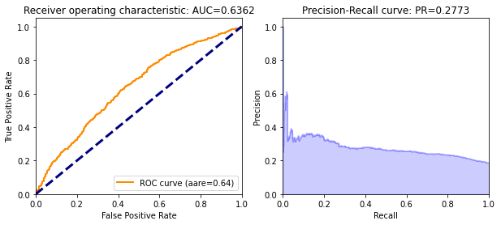

```python
def ROC_AUC(my_result,df,target):
    from sklearn.metrics import roc_curve,auc
    from sklearn.metrics import average_precision_score
    from sklearn.metrics import precision_recall_curve
    import matplotlib.pyplot as plt

    # ROC
    y_actual = df[target].as_data_frame()
    y_pred = my_result.predict(df)['p1'].as_data_frame()
    fpr = list()
    tpr = list()
    roc_auc = list()
    fpr,tpr,_ = roc_curve(y_actual,y_pred)
    roc_auc = auc(fpr,tpr)

    # Precision-Recall
    average_precision = average_precision_score(y_actual,y_pred)

    print('')
    print('   * ROC curve: The ROC curve plots the true positive rate vs. the false rositive sate')
    print('')
    print('	  * The area under the curve (AUC): A value between 0.5 (random) and 1.0 (perfect), measuring the prediction accuracy')
    print('')
    print('   * Recall (R) = The number of true positives / (the number of true positives + the number of false negatives)')
    print('')

    # plotting
    plt.figure(figsize=(10,4))

    # ROC
    plt.subplot(1,2,1)
    plt.plot(fpr,tpr,color='darkorange',lw=2,label='ROC curve (aare=%0.2f)' % roc_auc)
    plt.plot([0,1],[0,1],color='navy',lw=3,linestyle='--')
    plt.xlim([0.0,1.0])
    plt.ylim([0.0,1.05])
    plt.xlabel('False Positive Rate')
    plt.ylabel('True Positive Rate')
    plt.title('Receiver operating characteristic: AUC={0:0.4f}'.format(roc_auc))
    plt.legend(loc='lower right')

    # Precision-Recall
    plt.subplot(1,2,2)
    precision,recall,_ = precision_recall_curve(y_actual,y_pred)
    plt.step(recall,precision,color='b',alpha=0.2,where='post')
    plt.fill_between(recall,precision,step='post',alpha=0.2,color='b')
    plt.xlabel('Recall')
    plt.ylabel('Precision')
    plt.ylim([0.0,1.05])
    plt.xlim([0.0,1.0])
    plt.title('Precision-Recall curve: PR={0:0.4f}'.format(average_precision))
    plt.show()
# Apply
ROC_AUC(GLM_modl,test_hex,'loan_default')
```

## 3.2 Data cleaning

```python
# Check NA
missing_values = df.isnull().sum()
missing_values_per = (df.isnull().sum() / df.isnull().count())

# Merge
r = pd.concat([missing_values, missing_values_per],axis=1, keys = ['Count_of_Missing','Percentage']).reset_index()
r.sort_values(by = ['Count_of_Missing'], ascending = False).head(15)
```

|  | index | Count_of_Missing | Percentage |
| --- | --- | --- | --- |
| 29 | TD048 | 79999 | 0.999988 |
| 34 | TD062 | 79999 | 0.999988 |
| 32 | TD055 | 79999 | 0.999988 |
| 28 | TD044 | 79997 | 0.999962 |
| 30 | TD051 | 79995 | 0.999938 |
| 33 | TD061 | 79990 | 0.999875 |
| 31 | TD054 | 79988 | 0.999850 |
| 20 | TD022 | 19598 | 0.244975 |
| 21 | TD023 | 7663 | 0.095787 |
| 22 | TD024 | 3694 | 0.046175 |
| 85 | MB005 | 2793 | 0.034912 |
| 23 | TD025 | 2550 | 0.031875 |
| 24 | TD026 | 1846 | 0.023075 |
| 25 | TD027 | 1697 | 0.021212 |
| 26 | TD028 | 1636 | 0.020450 |

```python
# Select variables have too much Null values (>10%)
r2 = r[r['Count_of_Missing'] >= 19598]
r2['index']

# Delete the above variables
features = ['TD022','TD044','TD048','TD051','TD054','TD055','TD061','TD062']
df2 = df.drop(features, axis='columns')
df2.columns
```

```
Index(['id', 'loan_default', 'AP001', 'AP002', 'AP003', 'AP004', 'AP005',
       'AP006', 'AP007', 'AP008', 'AP009', 'TD001', 'TD002', 'TD005', 'TD006',
       'TD009', 'TD010', 'TD013', 'TD014', 'TD015', 'TD023', 'TD024', 'TD025',
       'TD026', 'TD027', 'TD028', 'TD029', 'CR004', 'CR005', 'CR009', 'CR012',
       'CR015', 'CR017', 'CR018', 'CR019', 'PA022', 'PA023', 'PA028', 'PA029',
       'PA030', 'PA031', 'CD008', 'CD018', 'CD071', 'CD072', 'CD088', 'CD100',
       'CD101', 'CD106', 'CD107', 'CD108', 'CD113', 'CD114', 'CD115', 'CD117',
       'CD118', 'CD120', 'CD121', 'CD123', 'CD130', 'CD131', 'CD132', 'CD133',
       'CD135', 'CD136', 'CD137', 'CD152', 'CD153', 'CD160', 'CD162', 'CD164',
       'CD166', 'CD167', 'CD169', 'CD170', 'CD172', 'CD173', 'MB005', 'MB007'],
      dtype='object')
```

```python
# Find other NA's location
def null_cell(df):
    dfx = df2.copy()
    missing_values = dfx.isnull().sum()
    missing_values_per = dfx.isnull().sum() / dfx.isnull().count()
    null_values = pd.concat([missing_values, missing_values_per],axis=1, keys = ['the_null','the_null_perc'])
    null_values = null_values.sort_values('the_null',ascending=False)
    return null_values[null_values['the_null']>0]

fill_list = (null_cell(df)).index
fill_list
```

```
Index(['TD023', 'TD024', 'MB005', 'TD025', 'TD026', 'TD027', 'TD028', 'TD029',
       'PA023', 'CD118', 'CD117', 'CD115', 'CD114', 'PA022', 'PA028', 'CD121',
       'PA029', 'CD113', 'PA031', 'CD008', 'CD018', 'CD071', 'CD072', 'CD088',
       'CD100', 'CD101', 'CD106', 'CD120', 'PA030', 'CD123', 'CD160', 'CD173',
       'CD172', 'CD170', 'CD169', 'CD167', 'CD166', 'CD164', 'CD162', 'CD153',
       'CD130', 'CD152', 'CD137', 'CD136', 'CD135', 'CD133', 'CD132', 'CD131',
       'CD108', 'CD107'],
      dtype='object')
```

```python
# Fill in NA with means
df_mean = df2.copy()
for col in fill_list:
    df_mean.loc[:,col].fillna(df_mean.loc[:,col].mean(),inplace=True)

# Check NA
df_mean.isnull().sum()
```

```
id              0
loan_default    0
AP001           0
AP002           0
AP003           0
               ..
CD170           0
CD172           0
CD173           0
MB005           0
MB007           0
Length: 79, dtype: int64
```

```python
df2 = df_mean
```

## 3.3 Data reprocessing

```python
# Split data (60% in training, 40% in testing)
from sklearn.model_selection import train_test_split
train2, test2 = train_test_split(df2, test_size=0.40, random_state=42)
train2.shape
```

```
(48000, 79)
```

```python
# Check the distribution of variables
var = pd.DataFrame(train2.dtypes).reset_index()
var.columns = ['varname','dtype']
var['source'] = var['varname'].str[:2]
var['source'].value_counts()
```

```
CD    36
TD    16
AP     9
CR     8
PA     6
MB     2
id     1
lo     1
Name: source, dtype: int64
```

```python
# Caregorize variables, and remove a bad data field: AP004
MB_list = list(var[var['source']=='MB']['varname'])
AP_list = list(var[(var['source']=='AP') & (var['varname']!='AP004')]['varname'])
TD_list = list(var[var['source']=='TD']['varname'])
CR_list = list(var[var['source']=='CR']['varname'])
PA_list = list(var[var['source']=='PA']['varname'])
CD_list = list(var[var['source']=='CD']['varname'])
```

```python
# Check the distribution of y in train
train2['loan_default'].value_counts()
```

```
0    38736
1     9264
Name: loan_default, dtype: int64
```

```python
# Set important parameters
target='loan_default'
predictors2 = CR_list + TD_list + AP_list + MB_list + CR_list + PA_list
```

## 3.4 Comparing the results before and after variable modification

```python
# Data Slicing
train_smp2 = train2.sample(frac=0.1, random_state=1)
test_smp2 = test2.sample(frac=0.1, random_state=1)
train_hex2 = h2o.H2OFrame(train_smp2)
test_hex2 = h2o.H2OFrame(test_smp2)
```

```
Parse progress: |████████████████████████████████████████████████████████████████| (done) 100%
Parse progress: |████████████████████████████████████████████████████████████████| (done) 100%
```

```python
train_hex2.shape
```

```
(4800, 79)
```

```python
test_hex2.shape
```

```
(3200, 79)
```

```python
# Apply GLM model ()
from h2o.estimators.glm import H2OGeneralizedLinearEstimator
GLM_mod2 = H2OGeneralizedLinearEstimator(family= "binomial",
                                          lambda_search = True)

# Use the cut of training dataset
GLM_mod2.train(predictors2,target,training_frame=train_hex2)

GLM_mod2.predict(test_hex2)
```

```
glm Model Build progress: |
```

```
██████████████████████████████████████████████████████| (done) 100%
glm prediction progress: |███████████████████████████████████████████████████████| (done) 100%
```

| predict | p0 | p1 |
| --- | --- | --- |
| 1 | 0.758764 | 0.241236 |
| 0 | 0.864933 | 0.135067 |
| 1 | 0.79594 | 0.20406 |
| 1 | 0.816502 | 0.183498 |
| 0 | 0.863276 | 0.136724 |
| 1 | 0.72376 | 0.27624 |
| 1 | 0.822085 | 0.177915 |
| 1 | 0.668353 | 0.331647 |
| 0 | 0.889097 | 0.110903 |
| 0 | 0.843666 | 0.156334 |

```
glm prediction progress: |███████████████████████████████████████████████████████| (done) 100%

   * ROC curve: The ROC curve plots the true positive rate vs. the false rositive sate

	  * The area under the curve (AUC): A value between 0.5 (random) and 1.0 (perfect), measuring the prediction accuracy

   * Recall (R) = The number of true positives / (the number of true positives + the number of false negatives)
```

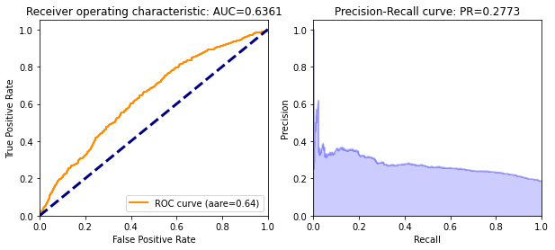

```python
# Apply
ROC_AUC(GLM_mod2,test_hex2,'loan_default')
```

## 3.5 Modify hyper-parameters

### 3.5.1 Lambda [0, 0.05, 0.1]

```python
# Apply GLM model ()
from h2o.estimators.glm import H2OGeneralizedLinearEstimator
GLM_mod3 = H2OGeneralizedLinearEstimator(family= "binomial",
                                         # when  lambda_ = 0 has the best result
                                         lambda_ = 0, # lambda_ =  [0, 0.05, 0.1]
                                         lambda_search = True)

# Use the cut of training dataset
GLM_mod3.train(predictors,target,training_frame=train_hex)

GLM_mod3.predict(test_hex)

# Apply
ROC_AUC(GLM_mod3,test_hex,'loan_default')
```

[output not shown]

```
glm Model Build progress: |
```

```
██████████████████████████████████████████████████████| (done) 100%
glm prediction progress: |███████████████████████████████████████████████████████| (done) 100%
```

```
glm prediction progress: |███████████████████████████████████████████████████████| (done) 100%

   * ROC curve: The ROC curve plots the true positive rate vs. the false rositive sate

	  * The area under the curve (AUC): A value between 0.5 (random) and 1.0 (perfect), measuring the prediction accuracy

   * Recall (R) = The number of true positives / (the number of true positives + the number of false negatives)
```

### 3.5.2 compute_p_values [T, F]

```python
# Apply GLM model ()
from h2o.estimators.glm import H2OGeneralizedLinearEstimator
GLM_mod4 = H2OGeneralizedLinearEstimator(family= "binomial",
                                         lambda_ = 0, # Modify1: lambda_ =  [0, 0.05, 0.1]
                                         # No big difference
                                         compute_p_values = True, # Modify2: T or F
                                         lambda_search = True)

# Use the cut of training dataset
GLM_mod4.train(predictors,target,training_frame=train_hex)

GLM_mod4.predict(test_hex)

# Apply
ROC_AUC(GLM_mod4,test_hex,'loan_default')
```

[output not shown]

```
glm Model Build progress: |
```

```
██████████████████████████████████████████████████████| (done) 100%
glm prediction progress: |███████████████████████████████████████████████████████| (done) 100%
glm prediction progress: |
```

```
███████████████████████████████████████████████████████| (done) 100%

   * ROC curve: The ROC curve plots the true positive rate vs. the false rositive sate

	  * The area under the curve (AUC): A value between 0.5 (random) and 1.0 (perfect), measuring the prediction accuracy

   * Recall (R) = The number of true positives / (the number of true positives + the number of false negatives)
```

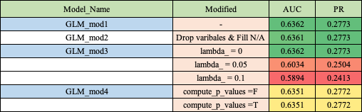

According to the results, the default model has the best performance.

```python
# Prediction
predictions = GLM_mod4.predict(test_hex)
predictions.head()
test_scores = test_hex['loan_default'].cbind(predictions).as_data_frame()
test_scores.head()
```

```
glm prediction progress: |███████████████████████████████████████████████████████| (done) 100%
```

|  | loan_default | predict | p0 | p1 | StdErr |
| --- | --- | --- | --- | --- | --- |
| 0 | 0 | 1 | 0.758278 | 0.241722 | 0.181066 |
| 1 | 0 | 0 | 0.864908 | 0.135092 | 0.218116 |
| 2 | 0 | 1 | 0.794287 | 0.205713 | 0.243006 |
| 3 | 0 | 1 | 0.817142 | 0.182858 | 0.193816 |
| 4 | 0 | 0 | 0.864558 | 0.135442 | 0.131660 |

```python
def createGains(model):
    predictions = model.predict(test_hex)
    test_scores = test_hex['loan_default'].cbind(predictions).as_data_frame()

    #sort on prediction (descending), add id, and decile for groups containing 1/10 of datapoints
    test_scores = test_scores.sort_values(by='predict',ascending=False)
    test_scores['row_id'] = range(0,0+len(test_scores))
    test_scores['decile'] = ( test_scores['row_id'] / (len(test_scores)/10) ).astype(int)
    #see count by decile
    test_scores.loc[test_scores['decile'] == 10]=9
    test_scores['decile'].value_counts()

    #create gains table
    gains = test_scores.groupby('decile')['loan_default'].agg(['count','sum'])
    gains.columns = ['count','actual']
    gains

    #add features to gains table
    gains['non_actual'] = gains['count'] - gains['actual']
    gains['cum_count'] = gains['count'].cumsum()
    gains['cum_actual'] = gains['actual'].cumsum()
    gains['cum_non_actual'] = gains['non_actual'].cumsum()
    gains['percent_cum_actual'] = (gains['cum_actual'] / np.max(gains['cum_actual'])).round(2)
    gains['percent_cum_non_actual'] = (gains['cum_non_actual'] / np.max(gains['cum_non_actual'])).round(2)
    gains['if_random'] = np.max(gains['cum_actual']) /10
    gains['if_random'] = gains['if_random'].cumsum()
    gains['lift'] = (gains['cum_actual'] / gains['if_random']).round(2)
    gains['K_S'] = np.abs( gains['percent_cum_actual'] -  gains['percent_cum_non_actual'] ) * 100
    gains['gain']=(gains['cum_actual']/gains['cum_count']*100).round(2)
    gains = pd.DataFrame(gains)
    return(gains)

createGains(GLM_mod4)
```

```
glm prediction progress: |███████████████████████████████████████████████████████| (done) 100%
```

| decile | count | actual | non_actual | cum_count | cum_actual | cum_non_actual | percent_cum_actual | percent_cum_non_actual | if_random | lift | K_S | gain |
| --- | --- | --- | --- | --- | --- | --- | --- | --- | --- | --- | --- | --- |
| 0 | 320 | 89 | 231 | 320 | 89 | 231 | 0.15 | 0.09 | 60.0 | 1.48 | 6.0 | 27.81 |
| 1 | 320 | 77 | 243 | 640 | 166 | 474 | 0.28 | 0.18 | 120.0 | 1.38 | 10.0 | 25.94 |
| 2 | 320 | 89 | 231 | 960 | 255 | 705 | 0.42 | 0.27 | 180.0 | 1.42 | 15.0 | 26.56 |
| 3 | 320 | 60 | 260 | 1280 | 315 | 965 | 0.52 | 0.37 | 240.0 | 1.31 | 15.0 | 24.61 |
| 4 | 320 | 79 | 241 | 1600 | 394 | 1206 | 0.66 | 0.46 | 300.0 | 1.31 | 20.0 | 24.62 |
| 5 | 320 | 36 | 284 | 1920 | 430 | 1490 | 0.72 | 0.57 | 360.0 | 1.19 | 15.0 | 22.40 |
| 6 | 320 | 31 | 289 | 2240 | 461 | 1779 | 0.77 | 0.68 | 420.0 | 1.10 | 9.0 | 20.58 |
| 7 | 320 | 47 | 273 | 2560 | 508 | 2052 | 0.85 | 0.79 | 480.0 | 1.06 | 6.0 | 19.84 |
| 8 | 320 | 43 | 277 | 2880 | 551 | 2329 | 0.92 | 0.90 | 540.0 | 1.02 | 2.0 | 19.13 |
| 9 | 320 | 49 | 271 | 3200 | 600 | 2600 | 1.00 | 1.00 | 600.0 | 1.00 | 0.0 | 18.75 |

### **3.6.1 Gains Table**

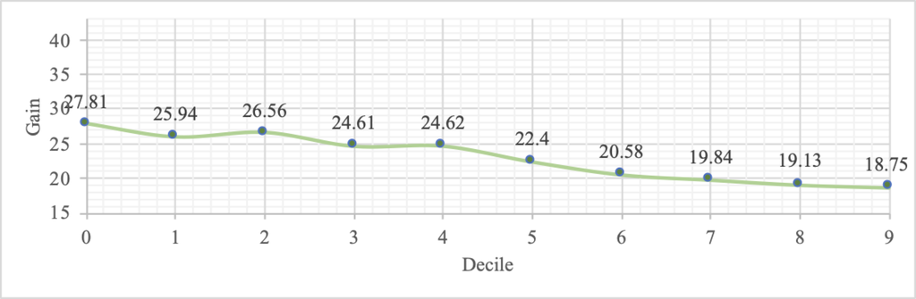

The purposes of gains table is to help analyst **select the model with better performance**, and **decide the segments should be focused on**.

According to the results, combining the mortgage business insight, there will be 27.81% (0.2781 * 320 = 89) customer in **decile 0** are bad loan applicants.

(*cum_actual* refers to the cumulative number of people who are actually unable to repay the loan.)

### **3.6.2 Lift**

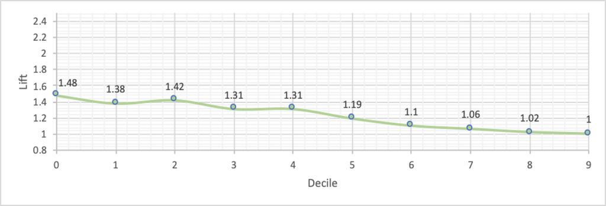

lift = cum_actual / if_random, which shows how much the bank can avoid bad applicants compared to banks randomly granting loans to customers.

Based on the results of the linear visualization between lift and Decile, it can be seen that the slope is most dramatic between Decile 4 to Decile 5. Therefore, from the lift perspective, the bank should **avoid applicants located through Decile 0 to Decile 5.**

### **3.6.3 Kolmogorov-Smirnov (K-S)**

K-S = |Cumultative % good — Cumulative % bad|, which measures the degree of separation between the distributions of the good and bad applicants.

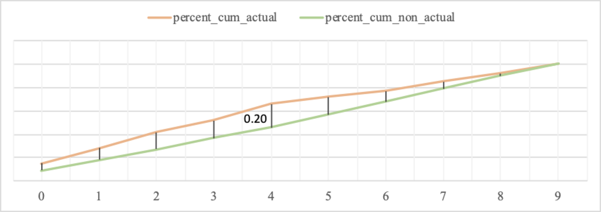

Frist of all, the K-S value for each deciles is not all 0, therefore the model effectively separate bad applicants from all customers. According to the figure above, I also find that the K-S value of Decile 4 reach to the maximum value of 0.2. In other words according to the results of K-S, the bank should **avoid applicants located through Decile 0 to Decile 4.**

### 3.6.4 ROC and PR Curves

```python
ROC_AUC(GLM_mod4,test_hex,'loan_default')
```

[output not shown]

```
glm prediction progress: |███████████████████████████████████████████████████████| (done) 100%

   * ROC curve: The ROC curve plots the true positive rate vs. the false rositive sate

	  * The area under the curve (AUC): A value between 0.5 (random) and 1.0 (perfect), measuring the prediction accuracy

   * Recall (R) = The number of true positives / (the number of true positives + the number of false negatives)
```

**`Interpretation:`**

**Receiver operating characteristic (ROC) curve** visualizes the accuracy of predictions for a whole range of cutoff values. The AUC value is 0.63 which means the performance of the model is **poor**.

**Precision-Recall (PR) curves**, on the other hand, is more informative than ROC when dealing with highly skewed datasets. Since the value of average precision for the PR curve is only 0.2772, the dataset is **skewed and needed to be balanced.**

# 4. auto Machine Learning

**What is AutoML?**

Deep Neural Networks in particular are notoriously difficult to tune properly. Therefore, H2O package designed an easy-to-use interface which automates the process of training a large selection of candidate models.

```python
from h2o.automl import H2OAutoML

# Run AutoML for 20 base models (limited to 1 hour max runtime by default)
aml_modl = H2OAutoML(max_runtime_secs = 60, max_models=20, seed=1)

# Use the cut of training dataset
aml_modl.train(predictors,target,training_frame=train_hex)
aml_modl.predict(test_hex)
```

[output not shown]

| predict |
| --- |
| 0.245087 |
| 0.146986 |
| 0.178348 |
| 0.163205 |
| 0.134303 |
| 0.257439 |
| 0.158125 |
| 0.30727 |
| 0.135461 |
| 0.159373 |

```python
# Check the leaderboard of models
aml_modl.leaderboard.head()
```

| model_id | rmse | mse | mae | rmsle | mean_residual_deviance |
| --- | --- | --- | --- | --- | --- |
| GLM_1_AutoML_1_20220802_190215 | 0.383407 | 0.147001 | 0.29361 | 0.26904 | 0.147001 |
| GBM_1_AutoML_1_20220802_190215 | 0.385855 | 0.148884 | 0.2949 | 0.271125 | 0.148884 |
| XGBoost_1_AutoML_1_20220802_190215 | 0.432059 | 0.186675 | 0.325302 | 0.31726 | 0.186675 |
| XGBoost_2_AutoML_1_20220802_190215 | 0.43703 | 0.190995 | 0.324589 | 0.318781 | 0.190995 |

```python
# Check the performance of the best model
perf = aml_modl.leader.model_performance(test_hex)
perf
```

```
ModelMetricsRegressionGLM: glm
** Reported on test data. **

MSE: 0.145936601513032
RMSE: 0.38201649377092606
MAE: 0.2942025063299967
RMSLE: 0.2684240948260235
R^2: 0.0420571798118925
Mean Residual Deviance: 0.145936601513032
Null degrees of freedom: 3199
Residual degrees of freedom: 3123
Null deviance: 487.50055555552717
Residual deviance: 466.99712484170243
AIC: 3078.541051569885
```

In this case, GLM is the most suitable model for this dataset and its prediction is the most accurate.

## 4.1 Comparing the results before and after variable modification

Similarly, I would like to further apply the modified dataset (remove variables + fill nulls) on the autoML model to compare the performance.

```python
from h2o.automl import H2OAutoML

# Run AutoML for 20 base models (limited to 1 hour max runtime by default)
aml_mod2 = H2OAutoML(max_runtime_secs = 60, max_models=20, seed=1)

# Use the cut of training dataset
aml_mod2.train(predictors2,target,training_frame=train_hex2)
aml_mod2.predict(test_hex2)
```

[output not shown]

| predict |
| --- |
| 0.24386 |
| 0.147031 |
| 0.175148 |
| 0.164961 |
| 0.137658 |
| 0.263485 |
| 0.15479 |
| 0.305395 |
| 0.140396 |
| 0.155623 |

```python
# Check the leaderboard of models
aml_mod2.leaderboard.head()
```

| model_id | rmse | mse | mae | rmsle | mean_residual_deviance |
| --- | --- | --- | --- | --- | --- |
| GLM_1_AutoML_2_20220802_190334 | 0.383427 | 0.147016 | 0.293647 | 0.269055 | 0.147016 |
| GBM_1_AutoML_2_20220802_190334 | 0.384267 | 0.147661 | 0.293289 | 0.269827 | 0.147661 |
| GBM_2_AutoML_2_20220802_190334 | 0.387223 | 0.149942 | 0.293617 | 0.272286 | 0.149942 |
| GBM_3_AutoML_2_20220802_190334 | 0.390423 | 0.15243 | 0.295487 | 0.274907 | 0.15243 |
| GBM_4_AutoML_2_20220802_190334 | 0.390834 | 0.152751 | 0.295371 | 0.275842 | 0.152751 |
| DRF_1_AutoML_2_20220802_190334 | 0.394995 | 0.156021 | 0.30442 | 0.281014 | 0.156021 |
| XGBoost_3_AutoML_2_20220802_190334 | 0.402016 | 0.161617 | 0.296537 | 0.285224 | 0.161617 |
| XGBoost_1_AutoML_2_20220802_190334 | 0.438119 | 0.191948 | 0.328651 | 0.321449 | 0.191948 |
| XGBoost_2_AutoML_2_20220802_190334 | 0.438275 | 0.192085 | 0.32641 | 0.319714 | 0.192085 |

```python
# Check the performance of the best model
perf = aml_mod2.leader.model_performance(test_hex2)
perf
```

```
ModelMetricsRegressionGLM: glm
** Reported on test data. **

MSE: 0.1459686846099352
RMSE: 0.3820584832325219
MAE: 0.2942945297708467
RMSLE: 0.2684644126627207
R^2: 0.04184658307324585
Mean Residual Deviance: 0.1459686846099352
Null degrees of freedom: 3199
Residual degrees of freedom: 3126
Null deviance: 487.50055555552717
Residual deviance: 467.0997907517926
AIC: 3073.244470900636
```

## 4.2 Interpretation of the performance of the AutoML model

```python
createGains(aml_mod2)
```

```
glm prediction progress: |███████████████████████████████████████████████████████| (done) 100%
```

| decile | count | actual | non_actual | cum_count | cum_actual | cum_non_actual | percent_cum_actual | percent_cum_non_actual | if_random | lift | K_S | gain |
| --- | --- | --- | --- | --- | --- | --- | --- | --- | --- | --- | --- | --- |
| 0 | 320 | 105 | 215 | 320 | 105 | 215 | 0.18 | 0.08 | 60.0 | 1.75 | 10.0 | 32.81 |
| 1 | 320 | 87 | 233 | 640 | 192 | 448 | 0.32 | 0.17 | 120.0 | 1.60 | 15.0 | 30.00 |
| 2 | 320 | 83 | 237 | 960 | 275 | 685 | 0.46 | 0.26 | 180.0 | 1.53 | 20.0 | 28.65 |
| 3 | 320 | 69 | 251 | 1280 | 344 | 936 | 0.57 | 0.36 | 240.0 | 1.43 | 21.0 | 26.88 |
| 4 | 320 | 70 | 250 | 1600 | 414 | 1186 | 0.69 | 0.46 | 300.0 | 1.38 | 23.0 | 25.87 |
| 5 | 320 | 51 | 269 | 1920 | 465 | 1455 | 0.78 | 0.56 | 360.0 | 1.29 | 22.0 | 24.22 |
| 6 | 320 | 46 | 274 | 2240 | 511 | 1729 | 0.85 | 0.66 | 420.0 | 1.22 | 19.0 | 22.81 |
| 7 | 320 | 44 | 276 | 2560 | 555 | 2005 | 0.92 | 0.77 | 480.0 | 1.16 | 15.0 | 21.68 |
| 8 | 320 | 25 | 295 | 2880 | 580 | 2300 | 0.97 | 0.88 | 540.0 | 1.07 | 9.0 | 20.14 |
| 9 | 320 | 20 | 300 | 3200 | 600 | 2600 | 1.00 | 1.00 | 600.0 | 1.00 | 0.0 | 18.75 |

### 4.2.1 Gains Table

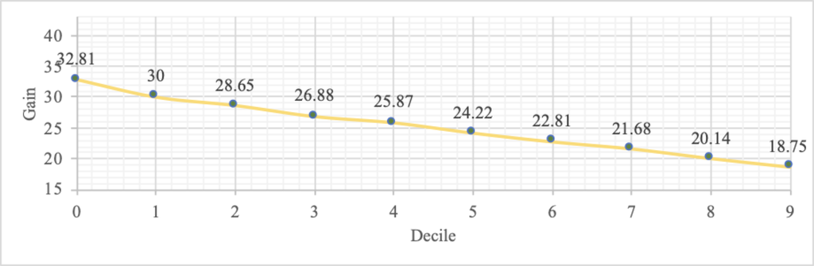

According to the results, combining the mortgage business insight, there will be 32.81% (0.3281 * 320 = 105) customer in decile 0 are bad loan applicants.

### 4.2.2 Lift

[figure not shown]

lift = cum_actual / if_random, which shows how much the bank can avoid bad applicants compared to banks randomly granting loans to customers.

### 4.2.3 K-S

[figure not shown]

# Summary

Taking all the above analysis into account, I think if the bank wants to expand its loan business, it can consider applicants from **Decile 5 to Decile 9**; if the bank wants to recover most of the loans securely and ensure profitability, it should consider applicants from **Decile 6 to Decile 9.**

```python
%%shell
jupyter nbconvert --to html /content/5420_A10_zl3121.ipynb
```

```
[NbConvertApp] Converting notebook /content/5420_A10_zl3121.ipynb to html
[NbConvertApp] Writing 3801133 bytes to /content/5420_A10_zl3121.html
```